# 1. Professional and academic services

I have provided extensive professional and academic service to sustain the scholarly community and advance institutional missions, including conducting peer reviews for scientific journals and mentoring, training, and advising emerging researchers and students. Several of these initiatives were carried out through Ecodiversa Tropical, a Colombian NGO dedicated to biodiversity conservation.

**Training**

### Training junior scientists and conservation practitioners

I am committed to creating opportunities for early-career scientists and practitioners to build skills in data analysis and modeling for conservation. To that end, [Prof. Melissa Guzmán](https://edslab.org/) (Cornell University) and I developed a series of Spanish-language R tutorials (see [GitHub repo](https://github.com/juanzuloaga?tab=repositories)) designed to train Colombian undergraduate and graduate students alongside conservation practitioners. We also successfully raised funds to help bridge the conservation genetics knowledge gap across the Spanish-speaking Global South (see [Experiment initiative](https://experiment.com/projects/bridging-the-conservation-genetics-knowledge-gap-in-the-spanish-speaking-global-south)).

Here is a look at the workshops we have developed so far:

**Taller motivacional**

Al final de este [taller motivacional](https://juanzuloaga.github.io/Intro_Motivacional/Intro_Motivacional.html) usted podrá responder a:

- Por qué es importante desarrollar habilidades computacionales y de análisisi de datos?

- Por qué R y R Studio?

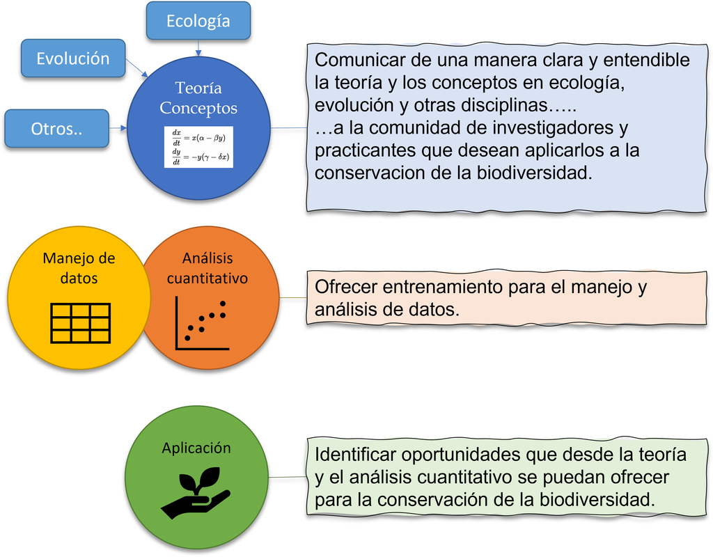

*Esquema conceptual de nuestro propósito con estos talleres*

**Introducción a R**

Al final de este [Taller básico en R](https://juanzuloaga.github.io/IntroR_Bases/IntroR_Bases.html) usted podrá saber cómo:

- Usar R como calculadora
- Identificar y usar varios tipos de datos (ej: numéricos, caracteres)
- Crear un objeto y asignar valores al objeto
- Identificar y crear estructuras de datos (ej: vectores, data frames, listas y matrices)
- Aplicar funciones básicas matemáticas y estadísticas
- Enteder qué son funciones y paquetes en R
- Saber utilizar las ayudas en R

[figure not shown]

*Pantallazo de R-Studio mostrando los paneles y su utilidad*

**Configurar R**

Al final de este taller de [Configuración](https://juanzuloaga.github.io/IntroR_Configurar/IntroR_Configurar.html) usted podrá:

- Crear carpetas
- Configurar directorio de trabajo
- Salvar código en R
- Crear un proyecto
- Crear rutas absoluta y relativa

[figure not shown]

*Crear un proyecto*

**Visualización de datos**

Al final de éste taller de [Visualización de datos](https://juanzuloaga.github.io/IntroR_Plots/IntroR_Plots.html), podrás aprender cómo:

- Definir el concepto de capas en un gráfico.
- Crear un “gráfico de caja” (box plot).
- Crear un “gráfico de dispersión” (scatter plot).
- Crear un diagrama de dispersión incluyendo una “línea de regresión” (linear regression).
- Crear un “histograma” (histograma).
- Crear un “gráfico de barras” (bar graph).

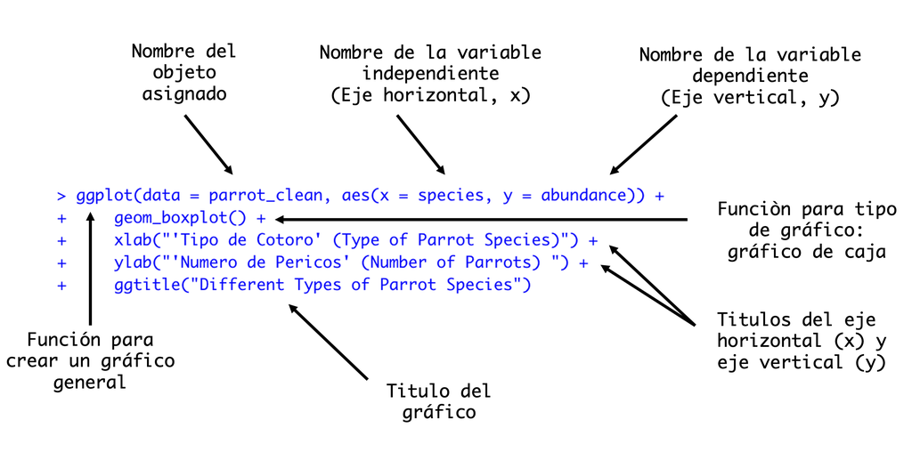

*Estructura general de un código en R para visualizar datos udando el paquete ggplot2*

**Manejo de datos**

Al final de este taller de [Manejo de datos](https://juanzuloaga.github.io/IntroR_ManejarDatos/IntroR_ManejarDatos.html), podrás aprender cómo:

- Agrupar y resumir datos usando el paquete “dplyr”.
- Usar las funciones mutate(), filter(), select(), group_by() y summarise() del paquete “dplyr” para modificar estructuras de datos.
- Usar las funciones group_by() y summarise() para analizar estructuras de datos.
- Cargar datos en varios formatos.
- Usar las funciones pivot_longer() y pivot_wider() del paquete “tidyr” para modificar la disposición de estructuras de datos. Usar las funciones str_replace() y str_remove() del paquete “stringr” para manipular caracteres en estructuras de datos.

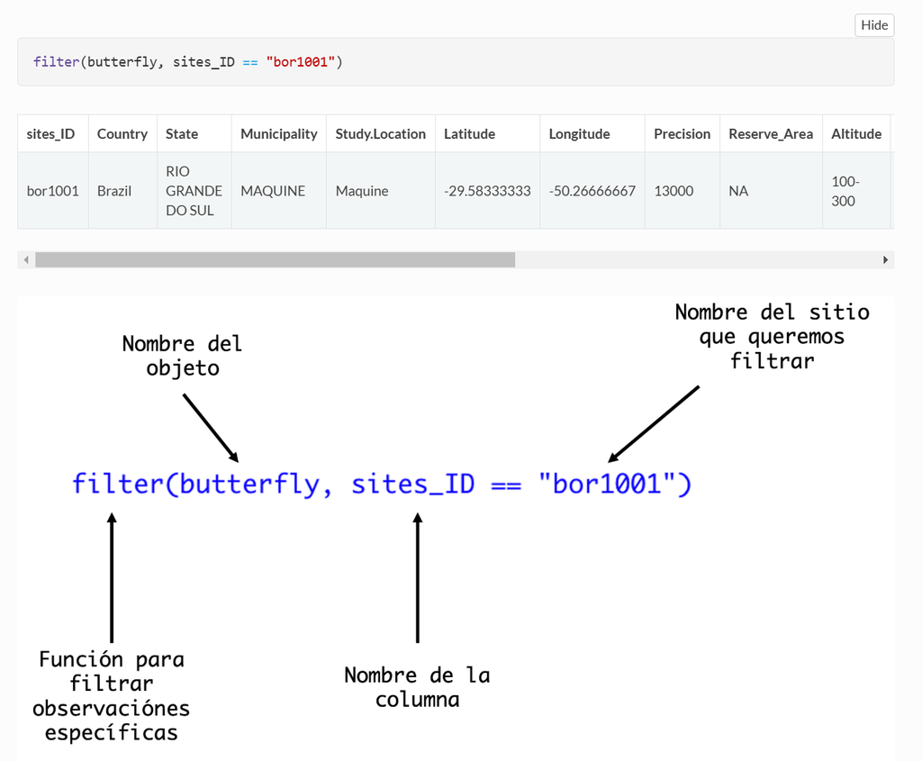

*Cómo filtrar datos en R usando dply::filter()*

**Análisis espacial**

Al final de este taller de [Análisis espacial](https://juanzuloaga.github.io/IntroR_espacial/Intro_espacial.html)usted podrá:

- Identificar las características de los datos espaciales, en sus dos formatos: ráster y vectorial.
- Conocer los paquetes y funciones en R más utilizados para el manejo de los dos formatos.
- Utilizar bases de datos de libre acceso disponibles en la web.
- Integrar y graficar los dos formatos
- Implemetar algunos análisis espaciales que pueden servir de herramientas para la toma de decisiones en la conservación de la biodiversidad.

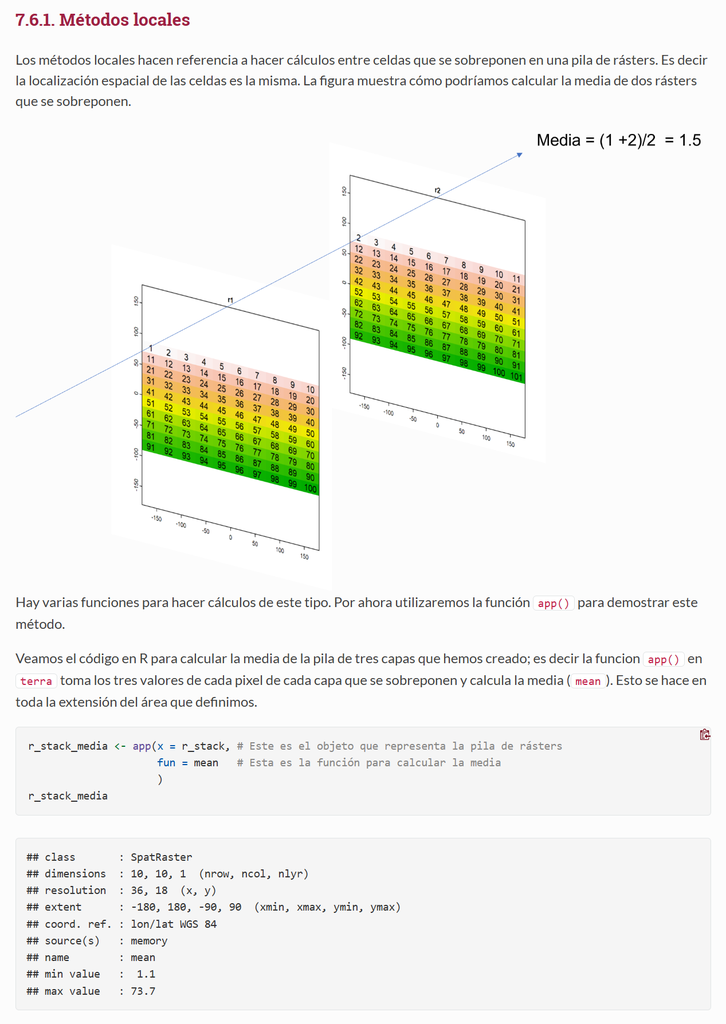

*Métodos locales en análisis espacial*

**Peer review**

I have served as an evaluator for Ecography (2) and EcoSience (1) peer-review journals.

- Evaluated original research manuscripts for methodology, statistical validity, and clarity.
- Provided critical, constructive feedback to authors to improve manuscript quality.
- Delivered recommendations to the Editorial Board regarding publication readiness.

**Mentorship**

Over the past five years, I have mentored more than 10 students in Colombia, focusing on building their technical capacity in coding and spatial analysis.

Beyond technical training, I have guided them through the graduate school application process, reviewing resumes, CVs, and portfolios, and helping them build personal websites to showcase their work.

I have also collaborated with mentees on the conceptualization, design, and data analysis of graduate research projects aimed at publication in peer-reviewed journals. For instance,

- García-Atencia, et al. (2026). [Landscape configuration outweighs composition in shaping the diversity of phytophagous scarab beetles in the Serranía del Perijá, Colombia.](https://www.sciencedirect.com/science/article/pii/S2530064426000611). *Perspectives in Ecology and Conservation.* 24(4):426-433.

**Webinars**

During the COVID-19 pandemic, I organized a 10-part webinar series titled Estudiantes aprendiendo de estudiantes (Students Learning from Students). The series provided a platform for graduate students to share their research and personal academic journeys, aiming to inform, mentor, and inspire undergraduate students to pursue graduate studies.

**See webinar series in YouTube**

Paola Carrión, McGill Univesity. Especies introducidas y ecosistemas insulares.

[video not shown]

Angely Vásquez, McGill University. Evolución y hormigas

[video not shown]

Juan Pablo Ramirez, Northern Brithish Columbia. Fragmentación y biodiversidad.

[video not shown]

Pablo Negret, The University of Queensland. Conservación de la biodiversidad.

[video not shown]

Felipe Miguel Libran, University of Göttingen. Control de plagas del café.

[video not shown]

Gonzalo Pinilla, City University of New York. Modelos de nicho ecológico.

[video not shown]

Sofía López-Cubillos, The University of Queensland. Servicios ecosistémicos.

[video not shown]

Juan Diego Martínez, University of British Columbia. Inequidad-Alimentación-Desarrollo sostenible.

[video not shown]

Carolina Montealegre, Universidad de Sao Pablo. Aves y paisajes antrópicos.

[video not shown]

Camilo Alejo, McGill University.

[video not shown]

# 2. Outreach

I have led impactful outreach and knowledge mobilization initiatives to bridge the gap between science and society, serving as a team leader, acting as a community liaison to foster local engagement, and training junior scientists in applied research and public communication.

**Communications**

[figure not shown]

**Community liaison**

**Team leader York University - COTERC. Tortuguero, Costa Rica (2010).**

- I helped local communities to develop environmental-community-based projects.
- I helped to open a social web to raise funds based on the number of miles walked by volunteers (Miles for Smiles) and the number of bottles removed from ‘Playa Norte’ (‘Pick it up’). Funds will be used to support community-based projects and postsecondary scholarships for local students.
- I helped to implement Zero plastic bags initiative aimed to: minimize local community’s reliance on plastic bags by distributing and encouraging the use of fabric bags made by local women.

**Interpreter, Red-cross. Toronto, Canada (2007-2010).**

Volunteered as a bilingual interpreter for the Canadian Red Cross Disaster Management team in Toronto, facilitating critical communication during emergency response operations.

**Meal assistant and interpreter, World Vision. Toronto, Canada (2006-2009).**

Volunteered as a bilingual interpreter and cook for the World Vision Refugee Center in Toronto.